# README

**REQUIRED** — A MailChimp.com account and API Key are required to use this module.

## Steps to finish setup

- Log into your [MailChimp.com](http://mailchimp.com) account
- Locate your API Key
- Locate your Newsletter List ID
- Enter your API Key and Newsletter List ID into Infinity Dashboard

## What is an API Key and why do I need it?

> An application programming interface key(API key) is a code passed in by computer programs calling an application programming interface (API) to identify the calling program, its developer, or its user to the Web site.

An API Key allows the MailChimp module access to the data stored on the MailChimp servers and allows us to look up the stats about the mailing lists.

## Locating your API Key

- Click the following link to open the [login page](http://mailchimp.com)
- Follow the on screen steps to log into your account.
- Once logged in, click on the **Account Name** located in the top right corner of the top toolbar.

[figure not shown]

- Click the **Profile** option in the dropdown that appears.

[figure not shown]

- Click on the **Extras** tab

[figure not shown]

- Then click on the **API Keys** item in the dropdown.

[figure not shown]

- Scroll down to the **Your API keys** section
- Locate the **API Key** column
- Click the text field in the first row to select the API Key
- Copy it by performing a `Right Click` and selecting the `Copy` action.

[figure not shown]

## Entering your API Key into Infinity Dashboard

- Open Infinity Dashboard
- Click on the ‘Module Config’ item in the sidebar
- Locate the MailChimp module you want to configure
- Click the Pencil icon to open the module configuration
- Locate the **MailChimp API Key** config option
- Click the **Click to edit this value** text field to edit the value.

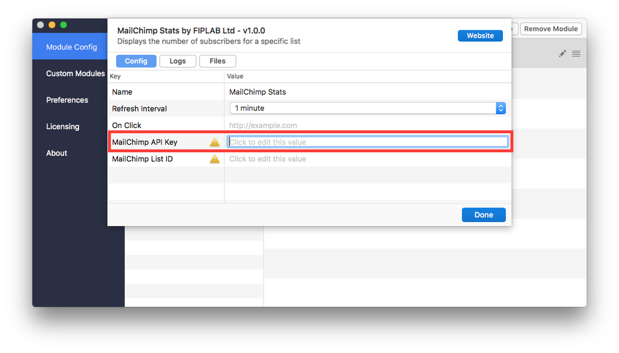

- Paste the copied API Key into the field by hitting `Command+V` or by `Right Clicking` the text field and selecting the `Paste` option.

## Locating your List ID

- Click the following link to open the [Lists page](https://us1.admin.mailchimp.com/lists/)
- Click the drop-down menu next to the list you want to work with, and choose Settings in the dropdown.

[figure not shown]

- Scroll to find the unique List ID field. The string of letters and numbers is the list ID.

[figure not shown]

## Entering your List ID into Infinity Dashboard

- Open Infinity Dashboard
- Click on the **Module Config** item in the sidebar
- Locate the **MailChimp module** you want to configure
- Click the **Pencil icon** to open the module configuration
- Locate the **MailChimp List ID** config option
- Click the **Click to edit this value** text field to edit the value.

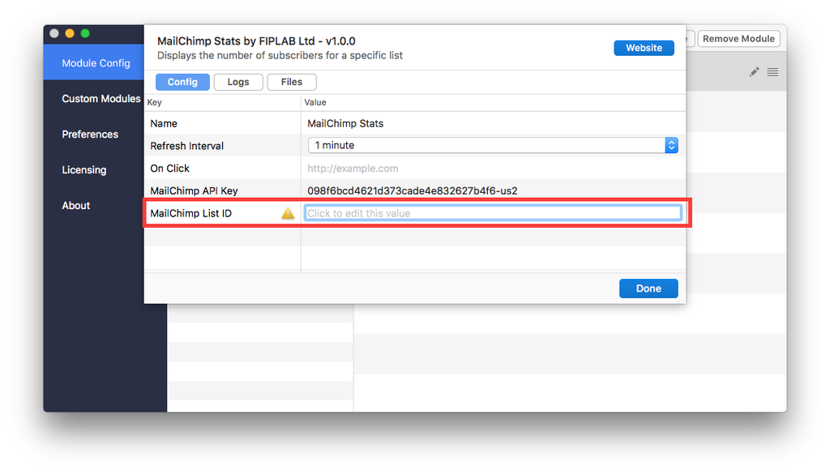

**Success** — You’re all set!